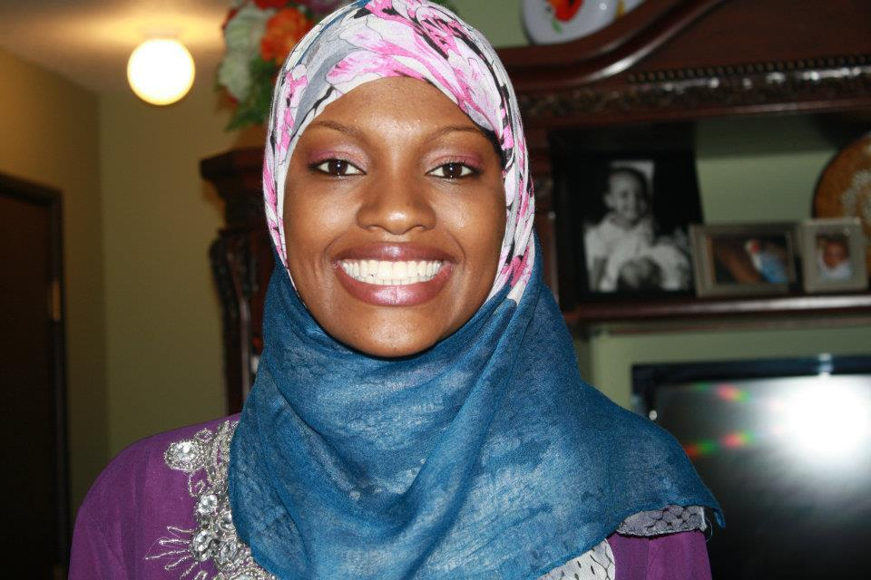

# Kadija Mussa

## Bio

Hello, my name is Kadija Mussa!

I am a Ph.D. student in Family Social Science specializing in Couples and Family Therapy. I am also working on a minor in data Analytics in the Education Psychology Department at the University of Minnesota. My research interest is in the experience of East African Immigrants in America. I use both qualitative and quantitative data to look at population level and interpersonal relationships.

In my free time I love to read and volunteering on different professional boards. I am currently looking to learn all about programming to be industry ready!

## Education

**University of Minnesota** | Twin-cities, MN

Ph.D. in Couple & Family Therapy Specialization | September 2021 - Present

**St. Cloud State University** | St. Could, MN

M.S. in Marriage and Family Therapy | 2019

**University of Minnesota** | Minneapolis, MN

B.A. in Psychology | 2012

B.A. in Biology, Society and Environment | 2012

## Experience

**Clinical Extern/ Ph.D. student** | September 2021 - Present

**Chemical Dependency Case Manager** | March 2020 - Present

**Mental Health Practitioner** | June 2018 - February 2019

**Mental Health Practicum** | May 2017 - June 2018